# Optimal Treatment Analysis

## Outcome Variable

**Outcome Variable:** whz

## Predictor Variables

**Intervention Variable:** earlybf

**Adjustment Set:**

- arm
- sex
- W_mage
- meducyrs
- feducyrs
- hhwealth_quart
- hfoodsec
- W_mhtcm
- W_mwtkg
- W_mbmi
- vagbrth
- W_gagebrth
- W_birthwt
- W_birthlen
- W_nrooms
- W_nchldlt5
- brthmon
- W_parity
- impfloor
- impsan
- safeh20
- delta_W_mage
- delta_meducyrs
- delta_feducyrs
- delta_hhwealth_quart
- delta_hfoodsec
- delta_W_mhtcm
- delta_W_mwtkg
- delta_W_mbmi
- delta_vagbrth
- delta_W_gagebrth
- delta_W_birthwt
- delta_W_birthlen
- delta_W_nrooms
- delta_W_nchldlt5
- delta_brthmon
- delta_W_parity
- delta_impfloor
- delta_impsan
- delta_safeh20

## Stratifying Variables

The analysis was stratified on these variable(s):

- agecat
- studyid
- country

## Data Summary

| agecat | studyid | country | earlybf | n_cell | n |
| --- | --- | --- | --- | --- | --- |
| Birth | ki0047075b-MAL-ED | BANGLADESH | 1 | 140 | 214 |
| Birth | ki0047075b-MAL-ED | BANGLADESH | 0 | 74 | 214 |
| Birth | ki0047075b-MAL-ED | BRAZIL | 1 | 26 | 62 |
| Birth | ki0047075b-MAL-ED | BRAZIL | 0 | 36 | 62 |
| Birth | ki0047075b-MAL-ED | INDIA | 1 | 31 | 44 |
| Birth | ki0047075b-MAL-ED | INDIA | 0 | 13 | 44 |
| Birth | ki0047075b-MAL-ED | NEPAL | 1 | 14 | 26 |
| Birth | ki0047075b-MAL-ED | NEPAL | 0 | 12 | 26 |
| Birth | ki0047075b-MAL-ED | PERU | 1 | 172 | 228 |
| Birth | ki0047075b-MAL-ED | PERU | 0 | 56 | 228 |
| Birth | ki0047075b-MAL-ED | SOUTH AFRICA | 1 | 69 | 110 |
| Birth | ki0047075b-MAL-ED | SOUTH AFRICA | 0 | 41 | 110 |
| Birth | ki0047075b-MAL-ED | TANZANIA, UNITED REPUBLIC OF | 1 | 103 | 115 |
| Birth | ki0047075b-MAL-ED | TANZANIA, UNITED REPUBLIC OF | 0 | 12 | 115 |
| Birth | ki1000109-EE | PAKISTAN | 1 | 36 | 170 |
| Birth | ki1000109-EE | PAKISTAN | 0 | 134 | 170 |
| Birth | ki1000304b-SAS-CompFeed | INDIA | 1 | 79 | 1072 |
| Birth | ki1000304b-SAS-CompFeed | INDIA | 0 | 993 | 1072 |
| Birth | ki1017093c-NIH-Crypto | BANGLADESH | 1 | 613 | 707 |
| Birth | ki1017093c-NIH-Crypto | BANGLADESH | 0 | 94 | 707 |
| Birth | ki1113344-GMS-Nepal | NEPAL | 1 | 171 | 586 |
| Birth | ki1113344-GMS-Nepal | NEPAL | 0 | 415 | 586 |
| Birth | ki1126311-ZVITAMBO | ZIMBABWE | 1 | 6142 | 11514 |
| Birth | ki1126311-ZVITAMBO | ZIMBABWE | 0 | 5372 | 11514 |
| Birth | kiGH5241-JiVitA-3 | BANGLADESH | 1 | 124 | 22000 |
| Birth | kiGH5241-JiVitA-3 | BANGLADESH | 0 | 21876 | 22000 |
| Birth | kiGH5241-JiVitA-4 | BANGLADESH | 1 | 1624 | 2396 |
| Birth | kiGH5241-JiVitA-4 | BANGLADESH | 0 | 772 | 2396 |
| 6 months | ki0047075b-MAL-ED | BANGLADESH | 1 | 147 | 240 |
| 6 months | ki0047075b-MAL-ED | BANGLADESH | 0 | 93 | 240 |

[output cut: 52 more lines]

The following strata were considered:

- agecat: 24 months, studyid: ki0047075b-MAL-ED, country: BANGLADESH
- agecat: 24 months, studyid: ki0047075b-MAL-ED, country: BRAZIL
- agecat: 24 months, studyid: ki0047075b-MAL-ED, country: INDIA
- agecat: 24 months, studyid: ki0047075b-MAL-ED, country: NEPAL
- agecat: 24 months, studyid: ki0047075b-MAL-ED, country: PERU
- agecat: 24 months, studyid: ki0047075b-MAL-ED, country: SOUTH AFRICA
- agecat: 24 months, studyid: ki0047075b-MAL-ED, country: TANZANIA, UNITED REPUBLIC OF
- agecat: 24 months, studyid: ki1000109-EE, country: PAKISTAN
- agecat: 24 months, studyid: ki1017093c-NIH-Crypto, country: BANGLADESH
- agecat: 24 months, studyid: ki1113344-GMS-Nepal, country: NEPAL
- agecat: 24 months, studyid: ki1126311-ZVITAMBO, country: ZIMBABWE
- agecat: 24 months, studyid: kiGH5241-JiVitA-3, country: BANGLADESH
- agecat: 24 months, studyid: kiGH5241-JiVitA-4, country: BANGLADESH
- agecat: 6 months, studyid: ki0047075b-MAL-ED, country: BANGLADESH
- agecat: 6 months, studyid: ki0047075b-MAL-ED, country: BRAZIL
- agecat: 6 months, studyid: ki0047075b-MAL-ED, country: INDIA
- agecat: 6 months, studyid: ki0047075b-MAL-ED, country: NEPAL
- agecat: 6 months, studyid: ki0047075b-MAL-ED, country: PERU
- agecat: 6 months, studyid: ki0047075b-MAL-ED, country: SOUTH AFRICA
- agecat: 6 months, studyid: ki0047075b-MAL-ED, country: TANZANIA, UNITED REPUBLIC OF
- agecat: 6 months, studyid: ki1000109-EE, country: PAKISTAN
- agecat: 6 months, studyid: ki1000304b-SAS-CompFeed, country: INDIA
- agecat: 6 months, studyid: ki1017093c-NIH-Crypto, country: BANGLADESH
- agecat: 6 months, studyid: ki1113344-GMS-Nepal, country: NEPAL
- agecat: 6 months, studyid: ki1126311-ZVITAMBO, country: ZIMBABWE
- agecat: 6 months, studyid: kiGH5241-JiVitA-3, country: BANGLADESH
- agecat: 6 months, studyid: kiGH5241-JiVitA-4, country: BANGLADESH
- agecat: Birth, studyid: ki0047075b-MAL-ED, country: BANGLADESH
- agecat: Birth, studyid: ki0047075b-MAL-ED, country: BRAZIL
- agecat: Birth, studyid: ki0047075b-MAL-ED, country: INDIA
- agecat: Birth, studyid: ki0047075b-MAL-ED, country: NEPAL
- agecat: Birth, studyid: ki0047075b-MAL-ED, country: PERU
- agecat: Birth, studyid: ki0047075b-MAL-ED, country: SOUTH AFRICA
- agecat: Birth, studyid: ki0047075b-MAL-ED, country: TANZANIA, UNITED REPUBLIC OF
- agecat: Birth, studyid: ki1000109-EE, country: PAKISTAN
- agecat: Birth, studyid: ki1000304b-SAS-CompFeed, country: INDIA
- agecat: Birth, studyid: ki1017093c-NIH-Crypto, country: BANGLADESH
- agecat: Birth, studyid: ki1113344-GMS-Nepal, country: NEPAL
- agecat: Birth, studyid: ki1126311-ZVITAMBO, country: ZIMBABWE
- agecat: Birth, studyid: kiGH5241-JiVitA-3, country: BANGLADESH
- agecat: Birth, studyid: kiGH5241-JiVitA-4, country: BANGLADESH

### Dropped Strata

Some strata were dropped due to rare outcomes:

- agecat: 24 months, studyid: kiGH5241-JiVitA-3, country: BANGLADESH

## Methods Detail

We’re interested in the causal parameters $E[Y_a]$ for all values of $a \in \mathcal{A}$. These parameters represent the mean outcome if, possibly contrary to fact, we intervened to set all units to have $A=a$. Under the randomization and positivity assumptions, these are identified by the statistical parameters $\psi_a=E_W[E_{Y|A,W}(Y|A=a,W)]$. In addition, we’re interested in the mean of $Y$, $E[Y]$ under no intervention (the observed mean). We will estimate these parameters by using SuperLearner to fit the relevant likelihood factors – $E_{Y|A,W}(Y|A=a,W)$ and $p(A=a|W)$, and then updating our likelihood fit using a joint TMLE.

For unadjusted analyses ($W=\{\}$), initial likelihoods were estimated using Lrnr_glm to estimate the simple $E(Y|A)$ and Lrnr_mean to estimate $p(A)$. For adjusted analyses, a small library containing Lrnr_glmnet, Lrnr_xgboost, and Lrnr_mean was used.

Having estimated these parameters, we will then use the delta method to estimate relative risks and attributable risks relative to a prespecified baseline level of $A$.

# Results Detail

## Results Plots

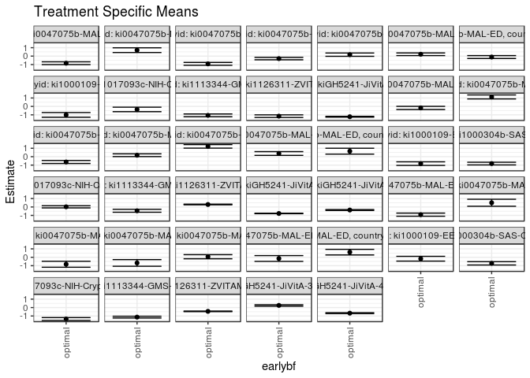

## Results Table

### Parameter: TSM

| agecat | studyid | country | intervention_level | baseline_level | estimate | ci_lower | ci_upper |
| --- | --- | --- | --- | --- | --- | --- | --- |
| Birth | ki0047075b-MAL-ED | BANGLADESH | optimal | observed | -0.9112592 | -1.0973635 | -0.7251549 |
| Birth | ki0047075b-MAL-ED | BRAZIL | optimal | observed | 0.4998870 | 0.0852997 | 0.9144743 |
| Birth | ki0047075b-MAL-ED | INDIA | optimal | observed | -0.8296813 | -1.1867255 | -0.4726370 |
| Birth | ki0047075b-MAL-ED | NEPAL | optimal | observed | -0.6719616 | -1.0658598 | -0.2780635 |
| Birth | ki0047075b-MAL-ED | PERU | optimal | observed | 0.0651609 | -0.1783550 | 0.3086768 |
| Birth | ki0047075b-MAL-ED | SOUTH AFRICA | optimal | observed | -0.1436439 | -0.4878554 | 0.2005676 |
| Birth | ki0047075b-MAL-ED | TANZANIA, UNITED REPUBLIC OF | optimal | observed | 0.6079854 | 0.2763380 | 0.9396329 |
| Birth | ki1000109-EE | PAKISTAN | optimal | observed | -0.1727056 | -0.4563424 | 0.1109313 |
| Birth | ki1000304b-SAS-CompFeed | INDIA | optimal | observed | -0.7195864 | -0.9168072 | -0.5223655 |
| Birth | ki1017093c-NIH-Crypto | BANGLADESH | optimal | observed | -1.3582243 | -1.5263144 | -1.1901341 |
| Birth | ki1113344-GMS-Nepal | NEPAL | optimal | observed | -1.1338150 | -1.2373083 | -1.0303218 |
| Birth | ki1126311-ZVITAMBO | ZIMBABWE | optimal | observed | -0.4503704 | -0.4859372 | -0.4148036 |
| Birth | kiGH5241-JiVitA-3 | BANGLADESH | optimal | observed | 0.2563541 | 0.1697125 | 0.3429957 |
| Birth | kiGH5241-JiVitA-4 | BANGLADESH | optimal | observed | -0.6664628 | -0.7261601 | -0.6067656 |
| 6 months | ki0047075b-MAL-ED | BANGLADESH | optimal | observed | -0.1805975 | -0.3695575 | 0.0083625 |
| 6 months | ki0047075b-MAL-ED | BRAZIL | optimal | observed | 1.1229175 | 0.8869337 | 1.3589014 |
| 6 months | ki0047075b-MAL-ED | INDIA | optimal | observed | -0.6262716 | -0.8064939 | -0.4460493 |
| 6 months | ki0047075b-MAL-ED | NEPAL | optimal | observed | 0.1760845 | 0.0120205 | 0.3401486 |
| 6 months | ki0047075b-MAL-ED | PERU | optimal | observed | 1.2260964 | 1.0154083 | 1.4367846 |
| 6 months | ki0047075b-MAL-ED | SOUTH AFRICA | optimal | observed | 0.3797133 | 0.1565884 | 0.6028382 |
| 6 months | ki0047075b-MAL-ED | TANZANIA, UNITED REPUBLIC OF | optimal | observed | 0.6550794 | 0.3056290 | 1.0045298 |
| 6 months | ki1000109-EE | PAKISTAN | optimal | observed | -0.8232658 | -1.0350655 | -0.6114661 |
| 6 months | ki1000304b-SAS-CompFeed | INDIA | optimal | observed | -0.8198983 | -0.9782320 | -0.6615646 |
| 6 months | ki1017093c-NIH-Crypto | BANGLADESH | optimal | observed | 0.0203191 | -0.1088979 | 0.1495360 |
| 6 months | ki1113344-GMS-Nepal | NEPAL | optimal | observed | -0.4504039 | -0.6249341 | -0.2758737 |
| 6 months | ki1126311-ZVITAMBO | ZIMBABWE | optimal | observed | 0.2962331 | 0.2580100 | 0.3344561 |
| 6 months | kiGH5241-JiVitA-3 | BANGLADESH | optimal | observed | -0.7712014 | -0.7973794 | -0.7450233 |
| 6 months | kiGH5241-JiVitA-4 | BANGLADESH | optimal | observed | -0.3602801 | -0.4141259 | -0.3064343 |
| 24 months | ki0047075b-MAL-ED | BANGLADESH | optimal | observed | -0.8424038 | -1.0091888 | -0.6756188 |
| 24 months | ki0047075b-MAL-ED | BRAZIL | optimal | observed | 0.7055720 | 0.4262831 | 0.9848608 |
| 24 months | ki0047075b-MAL-ED | INDIA | optimal | observed | -0.9199771 | -1.0898589 | -0.7500952 |
| 24 months | ki0047075b-MAL-ED | NEPAL | optimal | observed | -0.2943674 | -0.4372840 | -0.1514507 |
| 24 months | ki0047075b-MAL-ED | PERU | optimal | observed | 0.1718726 | -0.0240820 | 0.3678272 |
| 24 months | ki0047075b-MAL-ED | SOUTH AFRICA | optimal | observed | 0.2215083 | 0.0635736 | 0.3794429 |
| 24 months | ki0047075b-MAL-ED | TANZANIA, UNITED REPUBLIC OF | optimal | observed | -0.1105850 | -0.2821733 | 0.0610033 |
| 24 months | ki1000109-EE | PAKISTAN | optimal | observed | -1.0066051 | -1.2857195 | -0.7274907 |
| 24 months | ki1017093c-NIH-Crypto | BANGLADESH | optimal | observed | -0.3597515 | -0.6254708 | -0.0940321 |
| 24 months | ki1113344-GMS-Nepal | NEPAL | optimal | observed | -1.0642983 | -1.2296529 | -0.8989437 |
| 24 months | ki1126311-ZVITAMBO | ZIMBABWE | optimal | observed | -1.1573435 | -1.3140637 | -1.0006233 |
| 24 months | kiGH5241-JiVitA-4 | BANGLADESH | optimal | observed | -1.2264095 | -1.2760291 | -1.1767898 |

### Parameter: E(Y)

| agecat | studyid | country | intervention_level | baseline_level | estimate | ci_lower | ci_upper |
| --- | --- | --- | --- | --- | --- | --- | --- |
| Birth | ki0047075b-MAL-ED | BANGLADESH | observed | observed | -0.9384112 | -1.0842088 | -0.7926136 |
| Birth | ki0047075b-MAL-ED | BRAZIL | observed | observed | 0.4029032 | 0.0896793 | 0.7161272 |
| Birth | ki0047075b-MAL-ED | INDIA | observed | observed | -0.9122727 | -1.1899971 | -0.6345483 |
| Birth | ki0047075b-MAL-ED | NEPAL | observed | observed | -0.7684615 | -1.1257770 | -0.4111460 |
| Birth | ki0047075b-MAL-ED | PERU | observed | observed | -0.0520175 | -0.1725298 | 0.0684947 |
| Birth | ki0047075b-MAL-ED | SOUTH AFRICA | observed | observed | -0.1690000 | -0.3880340 | 0.0500340 |
| Birth | ki0047075b-MAL-ED | TANZANIA, UNITED REPUBLIC OF | observed | observed | 0.7624348 | 0.5710709 | 0.9537986 |
| Birth | ki1000109-EE | PAKISTAN | observed | observed | -0.3522059 | -0.5428560 | -0.1615557 |
| Birth | ki1000304b-SAS-CompFeed | INDIA | observed | observed | -0.6676026 | -0.8422097 | -0.4929956 |
| Birth | ki1017093c-NIH-Crypto | BANGLADESH | observed | observed | -1.2441513 | -1.3281130 | -1.1601897 |
| Birth | ki1113344-GMS-Nepal | NEPAL | observed | observed | -1.1260580 | -1.2184297 | -1.0336863 |
| Birth | ki1126311-ZVITAMBO | ZIMBABWE | observed | observed | -0.5262098 | -0.5537283 | -0.4986913 |
| Birth | kiGH5241-JiVitA-3 | BANGLADESH | observed | observed | -0.7500405 | -0.7678845 | -0.7321964 |
| Birth | kiGH5241-JiVitA-4 | BANGLADESH | observed | observed | -0.6886269 | -0.7410452 | -0.6362086 |
| 6 months | ki0047075b-MAL-ED | BANGLADESH | observed | observed | -0.1323472 | -0.2612119 | -0.0034826 |
| 6 months | ki0047075b-MAL-ED | BRAZIL | observed | observed | 0.9717225 | 0.8073791 | 1.1360658 |
| 6 months | ki0047075b-MAL-ED | INDIA | observed | observed | -0.7082698 | -0.8347304 | -0.5818092 |
| 6 months | ki0047075b-MAL-ED | NEPAL | observed | observed | 0.1110452 | -0.0202712 | 0.2423616 |
| 6 months | ki0047075b-MAL-ED | PERU | observed | observed | 1.0568987 | 0.9352990 | 1.1784983 |
| 6 months | ki0047075b-MAL-ED | SOUTH AFRICA | observed | observed | 0.5505800 | 0.3970988 | 0.7040612 |
| 6 months | ki0047075b-MAL-ED | TANZANIA, UNITED REPUBLIC OF | observed | observed | 0.5362213 | 0.4049390 | 0.6675036 |
| 6 months | ki1000109-EE | PAKISTAN | observed | observed | -0.7725778 | -0.8877440 | -0.6574117 |
| 6 months | ki1000304b-SAS-CompFeed | INDIA | observed | observed | -0.6657084 | -0.8024377 | -0.5289791 |
| 6 months | ki1017093c-NIH-Crypto | BANGLADESH | observed | observed | 0.0297622 | -0.0491685 | 0.1086930 |
| 6 months | ki1113344-GMS-Nepal | NEPAL | observed | observed | -0.5843738 | -0.6761994 | -0.4925481 |
| 6 months | ki1126311-ZVITAMBO | ZIMBABWE | observed | observed | 0.3072633 | 0.2799882 | 0.3345385 |
| 6 months | kiGH5241-JiVitA-3 | BANGLADESH | observed | observed | -0.5930207 | -0.6125866 | -0.5734549 |
| 6 months | kiGH5241-JiVitA-4 | BANGLADESH | observed | observed | -0.3898055 | -0.4270507 | -0.3525603 |
| 24 months | ki0047075b-MAL-ED | BANGLADESH | observed | observed | -0.8150711 | -0.9374454 | -0.6926967 |
| 24 months | ki0047075b-MAL-ED | BRAZIL | observed | observed | 0.4592308 | 0.2528453 | 0.6656163 |
| 24 months | ki0047075b-MAL-ED | INDIA | observed | observed | -0.9522907 | -1.0676596 | -0.8369219 |
| 24 months | ki0047075b-MAL-ED | NEPAL | observed | observed | -0.3764474 | -0.4898516 | -0.2630431 |
| 24 months | ki0047075b-MAL-ED | PERU | observed | observed | 0.1204478 | 0.0005049 | 0.2403906 |
| 24 months | ki0047075b-MAL-ED | SOUTH AFRICA | observed | observed | 0.4211915 | 0.2990776 | 0.5433054 |
| 24 months | ki0047075b-MAL-ED | TANZANIA, UNITED REPUBLIC OF | observed | observed | 0.0539486 | -0.0712465 | 0.1791437 |
| 24 months | ki1000109-EE | PAKISTAN | observed | observed | -1.0044512 | -1.1543739 | -0.8545285 |
| 24 months | ki1017093c-NIH-Crypto | BANGLADESH | observed | observed | -0.6103502 | -0.7050157 | -0.5156847 |
| 24 months | ki1113344-GMS-Nepal | NEPAL | observed | observed | -1.1339602 | -1.2266932 | -1.0412272 |
| 24 months | ki1126311-ZVITAMBO | ZIMBABWE | observed | observed | -1.1970712 | -1.3045749 | -1.0895676 |
| 24 months | kiGH5241-JiVitA-4 | BANGLADESH | observed | observed | -1.2231088 | -1.2549632 | -1.1912543 |

### Parameter: PAR

| agecat | studyid | country | intervention_level | baseline_level | estimate | ci_lower | ci_upper |
| --- | --- | --- | --- | --- | --- | --- | --- |
| Birth | ki0047075b-MAL-ED | BANGLADESH | optimal | observed | -0.0271520 | -0.1392458 | 0.0849418 |
| Birth | ki0047075b-MAL-ED | BRAZIL | optimal | observed | -0.0969838 | -0.3691186 | 0.1751509 |
| Birth | ki0047075b-MAL-ED | INDIA | optimal | observed | -0.0825915 | -0.2558962 | 0.0907133 |
| Birth | ki0047075b-MAL-ED | NEPAL | optimal | observed | -0.0964999 | -0.4716615 | 0.2786617 |
| Birth | ki0047075b-MAL-ED | PERU | optimal | observed | -0.1171785 | -0.3295311 | 0.0951741 |
| Birth | ki0047075b-MAL-ED | SOUTH AFRICA | optimal | observed | -0.0253561 | -0.2530044 | 0.2022922 |
| Birth | ki0047075b-MAL-ED | TANZANIA, UNITED REPUBLIC OF | optimal | observed | 0.1544493 | -0.0995007 | 0.4083994 |
| Birth | ki1000109-EE | PAKISTAN | optimal | observed | -0.1795003 | -0.4188915 | 0.0598909 |
| Birth | ki1000304b-SAS-CompFeed | INDIA | optimal | observed | 0.0519837 | -0.0909868 | 0.1949543 |
| Birth | ki1017093c-NIH-Crypto | BANGLADESH | optimal | observed | 0.1140729 | -0.0329339 | 0.2610797 |
| Birth | ki1113344-GMS-Nepal | NEPAL | optimal | observed | 0.0077570 | -0.0583575 | 0.0738715 |
| Birth | ki1126311-ZVITAMBO | ZIMBABWE | optimal | observed | -0.0758395 | -0.0994561 | -0.0522229 |
| Birth | kiGH5241-JiVitA-3 | BANGLADESH | optimal | observed | -1.0063946 | -1.0951548 | -0.9176343 |
| Birth | kiGH5241-JiVitA-4 | BANGLADESH | optimal | observed | -0.0221641 | -0.0670903 | 0.0227622 |
| 6 months | ki0047075b-MAL-ED | BANGLADESH | optimal | observed | 0.0482503 | -0.0712292 | 0.1677298 |
| 6 months | ki0047075b-MAL-ED | BRAZIL | optimal | observed | -0.1511951 | -0.3201227 | 0.0177326 |
| 6 months | ki0047075b-MAL-ED | INDIA | optimal | observed | -0.0819982 | -0.2295836 | 0.0655873 |
| 6 months | ki0047075b-MAL-ED | NEPAL | optimal | observed | -0.0650393 | -0.1749697 | 0.0448910 |
| 6 months | ki0047075b-MAL-ED | PERU | optimal | observed | -0.1691978 | -0.3409516 | 0.0025561 |
| 6 months | ki0047075b-MAL-ED | SOUTH AFRICA | optimal | observed | 0.1708667 | 0.0054735 | 0.3362599 |
| 6 months | ki0047075b-MAL-ED | TANZANIA, UNITED REPUBLIC OF | optimal | observed | -0.1188581 | -0.4324931 | 0.1947769 |
| 6 months | ki1000109-EE | PAKISTAN | optimal | observed | 0.0506880 | -0.1322108 | 0.2335867 |
| 6 months | ki1000304b-SAS-CompFeed | INDIA | optimal | observed | 0.1541899 | -0.0558474 | 0.3642272 |
| 6 months | ki1017093c-NIH-Crypto | BANGLADESH | optimal | observed | 0.0094432 | -0.0905785 | 0.1094648 |
| 6 months | ki1113344-GMS-Nepal | NEPAL | optimal | observed | -0.1339698 | -0.2789488 | 0.0110091 |
| 6 months | ki1126311-ZVITAMBO | ZIMBABWE | optimal | observed | 0.0110303 | -0.0157062 | 0.0377667 |
| 6 months | kiGH5241-JiVitA-3 | BANGLADESH | optimal | observed | 0.1781806 | 0.1555567 | 0.2008046 |
| 6 months | kiGH5241-JiVitA-4 | BANGLADESH | optimal | observed | -0.0295254 | -0.0678297 | 0.0087789 |
| 24 months | ki0047075b-MAL-ED | BANGLADESH | optimal | observed | 0.0273327 | -0.0841439 | 0.1388093 |
| 24 months | ki0047075b-MAL-ED | BRAZIL | optimal | observed | -0.2463412 | -0.4508300 | -0.0418524 |
| 24 months | ki0047075b-MAL-ED | INDIA | optimal | observed | -0.0323137 | -0.1670923 | 0.1024649 |
| 24 months | ki0047075b-MAL-ED | NEPAL | optimal | observed | -0.0820800 | -0.1793310 | 0.0151710 |
| 24 months | ki0047075b-MAL-ED | PERU | optimal | observed | -0.0514249 | -0.2098036 | 0.1069539 |
| 24 months | ki0047075b-MAL-ED | SOUTH AFRICA | optimal | observed | 0.1996832 | 0.0780434 | 0.3213231 |
| 24 months | ki0047075b-MAL-ED | TANZANIA, UNITED REPUBLIC OF | optimal | observed | 0.1645336 | 0.0336827 | 0.2953845 |
| 24 months | ki1000109-EE | PAKISTAN | optimal | observed | 0.0021539 | -0.2608880 | 0.2651958 |
| 24 months | ki1017093c-NIH-Crypto | BANGLADESH | optimal | observed | -0.2505987 | -0.4954678 | -0.0057296 |
| 24 months | ki1113344-GMS-Nepal | NEPAL | optimal | observed | -0.0696619 | -0.2113392 | 0.0720153 |
| 24 months | ki1126311-ZVITAMBO | ZIMBABWE | optimal | observed | -0.0397277 | -0.1497925 | 0.0703370 |
| 24 months | kiGH5241-JiVitA-4 | BANGLADESH | optimal | observed | 0.0033007 | -0.0349521 | 0.0415535 |